# Probabilidad y Estadística con Python

## ¿Qué es la Estadística?

La estadística suele ser definida como la ciencia de aprender de los datos o como la ciencia de obtener conclusiones en la presencia de incertidumbre. Se relaciona principalmente con la recolección, análisis e interpretación de datos, así como también con la efectiva comunicación y presentación de los resultados basados en esos datos. Como por datos entendemos a cualquier clase de información grabada, la estadística juego un rol importante en muchas disciplinas científicas.

La estadística suele ser dividida en dos grandes ramas:

La estadística descriptiva: La cual se dedica a recolectar, ordenar, analizar y representar a un conjunto de datos, con el fin de describir apropiadamente las características de este. Calcula los parámetros estadísticos que describen el conjunto estudiado. Algunas de las herramientas que utiliza son gráficos, medidas de frecuencias, medidas de centralización, medidas de posición, medidas de dispersión, entre otras.

La estadistica inferencial: La cual estudia cómo sacar conclusiones generales para toda la población a partir del estudio de una muestra, y el grado de fiabilidad o significación de los resultados obtenidos. Sus principales herramientas son el muestreo, la estimación de parámetros y el contraste de hipótesis.

## Conceptos básicos de la estadística descriptiva

En *[estadística descriptiva](https://es.wikipedia.org/wiki/Estad%C3%ADstica_descriptiva)* se utilizan distintas medidas para intentar describir las propiedades de nuestros datos, algunos de los conceptos básicos, son:

- **Media aritmética**: La [media aritmética](https://es.wikipedia.org/wiki/Media_aritm%C3%A9tica) es el valor obtenido al sumar todos los *[datos](https://es.wikipedia.org/wiki/Dato)* y dividir el resultado entre el número total elementos. Se suele representar con la letra griega $\mu$. Si tenemos una [muestra](https://es.wikipedia.org/wiki/Muestra_estad%C3%ADstica) de $n$ valores, $x_i$, la *media aritmética*, $\mu$, es la suma de los valores divididos por el numero de elementos; en otras palabras: $$\mu = \frac{1}{n} \sum_{i}x_i$$
- **Desviación respecto a la media**: La desviación respecto a la media es la diferencia en valor absoluto entre cada valor de la variable estadística y la media aritmética. $$D_i = |x_i - \mu|$$
- **Varianza**: La [varianza](https://es.wikipedia.org/wiki/Varianza) es la media aritmética del cuadrado de las desviaciones respecto a la media de una distribución estadística. La varianza intenta describir la dispersión de los *[datos](https://es.wikipedia.org/wiki/Dato)*. Se representa como $\sigma^2$. $$\sigma^2 = \frac{\sum\limits_{i=1}^n(x_i - \mu)^2}{n} $$
- **Desviación típica**: La [desviación típica](https://es.wikipedia.org/wiki/Desviaci%C3%B3n_t%C3%ADpica) es la raíz cuadrada de la varianza. Se representa con la letra griega $\sigma$. $$\sigma = \sqrt{\frac{\sum\limits_{i=1}^n(x_i - \mu)^2}{n}} $$
- **Moda**: La moda es el valor que tiene mayor frecuencia absoluta. Se representa con $M_0$
- **Mediana**: La mediana es el valor que ocupa el lugar central de todos los datos cuando éstos están ordenados de menor a mayor. Se representa con $\widetilde{x}$.

### Ejemplos en Python

Calcular los principales indicadores de la *[estadística descriptiva](https://es.wikipedia.org/wiki/Estad%C3%ADstica_descriptiva)* con [Python](http://python.org/) es muy fácil!.

```python
# Ejemplos de estadistica descriptiva con python

import numpy as np # importando numpy
from scipy import stats # importando scipy.stats
import pandas as pd # importando pandas

np.random.seed(2131982) # para poder replicar el random
```

```python
datos = np.random.randn(5, 4) # datos normalmente distribuidos
datos
```

```
array([[ 0.46038022, -1.08942528, -0.62681496, -0.63329028],
       [-0.1074033 , -0.88138082, -0.34466623, -0.28320214],
       [ 0.94051171,  0.86693793,  1.20947882, -0.16894118],
       [-0.12790177, -0.58099931, -0.46188426, -0.18148302],
       [-0.76959435, -1.37414587,  1.37696874, -0.18040537]])
```

```python
# media arítmetica
datos.mean() # Calcula la media aritmetica de
```

```
-0.14786303590303568
```

```python
np.mean(datos) # Mismo resultado desde la funcion de numpy
```

```
-0.14786303590303568
```

```python
datos.mean(axis=1) # media aritmetica de cada fila
```

```
array([-0.47228757, -0.40416312,  0.71199682, -0.33806709, -0.23679421])
```

```python
datos.mean(axis=0) # media aritmetica de cada columna
```

```
array([ 0.0791985 , -0.61180267,  0.23061642, -0.2894644 ])
```

```python
# mediana
np.median(datos)
```

```
-0.23234258265023794
```

```python
np.median(datos, 0) # media aritmetica de cada columna
```

```
array([-0.1074033 , -0.88138082, -0.34466623, -0.18148302])
```

```python
 # Desviación típica
np.std(datos)
```

```
0.73755354584071608
```

```python
np.std(datos, 0) # Desviación típica de cada columna
```

```
array([ 0.58057213,  0.78352862,  0.87384108,  0.17682485])
```

```python
# varianza
np.var(datos)
```

```
0.54398523298221324
```

```python
np.var(datos, 0) # varianza de cada columna
```

```
array([ 0.337064  ,  0.6139171 ,  0.76359823,  0.03126703])
```

```python
# moda
stats.mode(datos) # Calcula la moda de cada columna
# el 2do array devuelve la frecuencia.
```

```
(array([[-0.76959435, -1.37414587, -0.62681496, -0.63329028]]),
 array([[ 1.,  1.,  1.,  1.]]))
```

```python
datos2 = np.array([1, 2, 3, 6, 6, 1, 2, 4, 2, 2, 6, 6, 8, 10, 6])
stats.mode(datos2) # aqui la moda es el 6 porque aparece 5 veces en el vector.
```

```
ModeResult(mode=array([6]), count=array([5]))
```

## Practica :

Generar un modelo que me permita simular el uso de recursos de los hospitales por cada una de las provincias, para ello obtener la informacion revisada en la practica de investigacion y tomar como ejemplo la practica de simulacion de atencion de paciente del COVID revisada en clase. Lo que se busca es poder generar graficos de uso de recursos:

- Costos (Generar un aproximacion de cuanto se invierte para atender a un paciente con COVID)
- Personal (Aproximacion del uso del personal por paciente, o el hospital)
- Camas
- Equipos/Insumos medicos (Obtener una aproximacion del uso de equipos medicos)
- Pacientes (Informacion obtenida desde el ministerio de salud - validar con el porcentual del tipo de paciente [ninio 10%, adulto 30%, riesgo 60%]) - Hospitalizacion 80%, Otros 20%

Para ello deberan generar un modelo lo mas cercano a la realidad, y con ayuda de la estadistica descriptiva ajustar los valores. Es importante tener como datos de entrada el dia y el numero de pacientes.

Finalmente validar el modelo con lo la realidad del pais (Investigar en base al tema el uso de los recursos publicos )

```python
#Implementar
#Obtenemos la media para la tasa de crecimiento
import pandas as pd

url = 'Casos covid por provincias.xlsx'
df = pd.read_excel(url)
df = df.fillna(0)

start_date = '17/3/2020'
country_df = df[df['Provincia'] == 'SantaElena']
country_df = country_df.drop('16/3/2020',1)
country_df = country_df.drop('18/3/2020',1)
country_df = country_df.drop('19/3/2020',1)
media = country_df.iloc[0].loc[start_date:]
media = media.mean()
print('La media es de ',round(media))
```

```
La media es de  57.0
```

[output not shown]

[output cut: 6527 more lines]

```
El paciente 2706 contó con personal médico, luego de 4 horas
El paciente 2706 esperó 0 y se recuperá
Al paciente 2876  se le asigna una CAMA para ser atendido en 20 horas
Paciente 2921 esperó 21  horas y fallece por falta de CAMAS
El paciente 2652 ha sido dado de alta de HOSPITALIZACION en 42 dias
El paciente 2652 contó con personal médico, luego de 3 horas
El paciente 2652 esperó 0 y se recuperá
Al paciente 2880  se le asigna una CAMA para ser atendido en 22 horas
Paciente 2888 esperó 22  horas y fallece por falta de CAMAS
El paciente 2133 ha sido dado de alta de HOSPITALIZACION en 42 dias
El paciente 2133 contó con personal médico, luego de 3 horas
El paciente 2133 esperó 0 y se recuperá
Al paciente 2882  se le asigna una CAMA para ser atendido en 22 horas
Paciente 2915 esperó 23  horas y fallece por falta de CAMAS
Paciente 2892 esperó 23  horas y fallece por falta de CAMAS
```

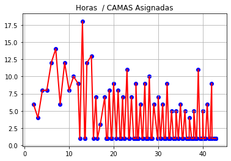

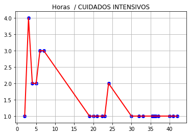

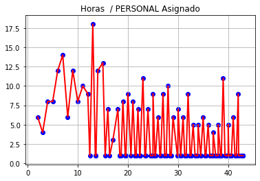

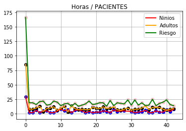

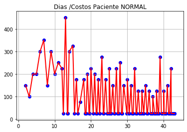

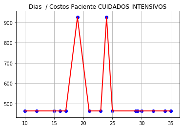

```python
#Implementar
##Primero sacamos la media
import simpy
import random
import matplotlib.pyplot as pp
import numpy as np

%matplotlib inline

#PARAMETROS
#Fuente https://www.elcomercio.com/actualidad/parroquia-santa-elena-muertos-coronavirus.html
HOSPITALES = 1
CAMA_HOSPITAL = 110
RESPIRADORES = 15
CUIDADOS_INTENSIVOS = 15
PERSONAL = 242
#Se divide el costo para el total de dias del tratamiento para saber el valor diario
COSTO_PACIENTE_NO_GRAVE = int(363/14)
COSTO_PACIENTE_GRAVE = int(6483/14)

#El valor de la tasa de crecimiento es la media de los nuevos casos presentados en SANTA ELENA
INFECTADOS_ACTULES = 534
TASA_CRECIMIENTO = 57
DIAS_INTERNADO = 10 #Tiempo en dias
DIAS_SIMULACION = 43 #Tiempo en dias

#Diccionario para almacenar los resultados
ninios = {}
adultos = {}
riesgo = {}
pacientes = {}
personalLabora = {}
total_camas = {}
total_respiradores = {}
intensivos_total = {}
persona_recuperadas={}
persona_fallecidas={}

#Lista
costoTotalTratamiento = []

class Hospital(object):
    def __init__(self, env, numero_camas, n_respiradores, personal, cuidados_intensivos, name):
            self.env = env
            self.numero_camas = numero_camas
            self.n_respiradores = n_respiradores
            self.camas = simpy.Resource(env, numero_camas)
            self.respiradores = simpy.Resource(env, n_respiradores)
            self.personal = simpy.Resource(env, personal)
            self.intensivos = simpy.Resource(env, cuidados_intensivos)
            self.name = name

    def asignar_cama_paciente(self, paciente):
        yield self.env.timeout(random.randint(DIAS_INTERNADO-8, DIAS_INTERNADO+5))
        print("El paciente", paciente, "ha sido dado de alta de HOSPITALIZACION en", int(self.env.now), 'dias')

    def cuidados_intensivos(self, paciente):
        yield self.env.timeout(random.randint(DIAS_INTERNADO-5, DIAS_INTERNADO+11))
        print("El paciente", paciente, "ha sido dado de alta de CUIDADOS INTENSIVOS en ", int(self.env.now), 'dias')

    def asignar_respiradores(self, paciente):
        yield self.env.timeout(random.randint(DIAS_INTERNADO-5, DIAS_INTERNADO+11))
        print("El paciente", paciente, "ya no requiere de un RESPIRADOR, luego de", int(self.env.now), 'dias')

def llegada_paciente(env, hospital, paciente):
    llegada = env.now
    hospitalizacion = random.randint(1,100)
    if (hospitalizacion < 80):
        tipo_paciente = random.randint(1,100)
        if(tipo_paciente <10):
            ninios[env.now] = ninios[env.now] + 1 if env.now in ninios else 1
        elif(tipo_paciente > 10 and tipo_paciente < 30):
            adultos[env.now] = adultos[env.now] + 1 if env.now in adultos else 1
        elif(tipo_paciente > 60):
            riesgo[env.now] = riesgo[env.now] + 1 if env.now in riesgo else 1

        with hospital.camas.request() as cama:
            llegada_cama = env.now
            #Esperara por una cama entre 14 horas y 36 horas
            tiempo_espera_cama=random.uniform(0.7,1.5)
            #tiempo_espera_cama=random.randint(1,1)
            requerimiento_cama = yield cama | env.timeout(tiempo_espera_cama)
            esperando = env.now - llegada_cama
            if cama in requerimiento_cama:
                print("Al paciente", paciente, " se le asigna una CAMA para ser atendido en", int(esperando*24), "horas")
                yield env.process(hospital.asignar_cama_paciente(paciente))
                total_camas[env.now] = total_camas[env.now] + 1 if env.now in total_camas else 1
                pacientes[env.now] = pacientes[env.now] + 1 if env.now in pacientes else 1
                estado_camas = random.randint(1,100)
                if (estado_camas < 8) :
                    persona_fallecidas[env.now] = persona_fallecidas[env.now] + 1 if env.now in persona_fallecidas else  1
                else:
                    persona_recuperadas[env.now] = persona_recuperadas[env.now] + 1 if env.now in persona_recuperadas else 1

                with hospital.personal.request() as personal:
                    llegada_personal = env.now
                    #Esperara por una cama entre 3 horas y 6 horas
                    tiempo_espera_personal=random.uniform(0.13,0.25)
                    requerimiento_personal = yield personal | env.timeout(tiempo_espera_personal)
                    espera_personal = env.now - llegada_personal
                    if personal in requerimiento_personal:
                        print("El paciente", paciente, "contó con personal médico, luego de",int(tiempo_espera_personal*24) ,"horas")
                        personalLabora[env.now] = personalLabora[env.now] + 1 if env.now in personalLabora else 1
                    #La probabilidad de que un paciente requiera el ingreso a CUIDADOS INTENSIVOS
                    #Por problemas de neumonia es de el 40% un 14% segun https://www.ciberes.org/noticias/la-neumonia-es-aun-una-de-las-enfermedades-mas-mortales-que-tenemos-y-no-se-le-ha-concedido-la-importancia-debida
                    #Al tener nosotros el doble de pacientes, es decir un 80%, se tendra el 28% de probabilidad

                    area_cuidados_intensivos = random.randint(1,100)
                    if (area_cuidados_intensivos < 28) :
                        with hospital.intensivos.request() as intensivo:
                            llegada_intensivos = env.now
                            #Espera de 8 a 16 horas
                            tiempo_espera_intensivo = random.uniform(0.33, 0.66)
                            requerimiento_intensivos = yield intensivo | env.timeout(tiempo_espera_intensivo)
                            espera_intensivo = env.now - llegada_intensivos
                            if(intensivo in requerimiento_intensivos):
                                print("El paciente", paciente, "es trasladado a CUIDADOS INTENSIVOS luego de", int(tiempo_espera_intensivo*24),"horas")
                                intensivos_total[env.now] = intensivos_total[env.now] + 1 if env.now in intensivos_total else 1
                                yield env.process(hospital.cuidados_intensivos(paciente))
                                estado_intensivos = random.randint(1,100)
                                if(estado_intensivos < 8):
                                    persona_fallecidas[env.now] = persona_fallecidas[env.now] + 1 if env.now in persona_fallecidas else  1
                                else:
                                    persona_recuperadas[env.now] = persona_recuperadas[env.now] + 1 if env.now in persona_recuperadas else 1

                                requiere_respirador = random.randint(1,100)
                                if(requiere_respirador < 87):
                                    with hospital.respiradores.request() as respirador:
                                        llegada_respirador = env.now
                                        requerimiento_respirador = yield respirador | env.timeout(0)
                                        espera_respirador = env.now - llegada_respirador
                                        if(respirador in requerimiento_respirador):
                                            print("Al paciente", paciente, "se le asigna un RESPIRADOR, en el area de CUIDADOS INTENSIVOS")
                                            total_respiradores[env.now] = total_respiradores[env.now] + 1 if env.now in total_respiradores else 1
                                            yield env.process(hospital.asignar_respiradores(paciente))
                                            estado_respirador = random.randint(1,100)
                                            if(estado_respirador < 8):
                                                persona_fallecidas[env.now] = persona_fallecidas[env.now] + 1 if env.now in persona_fallecidas else  1
                                            else:
                                                persona_recuperadas[env.now] = persona_recuperadas[env.now] + 1 if env.now in persona_recuperadas else 1
                                        else:
                                            print("El paciente " , paciente, " esperó ", int(espera_respirador) , " horas y fallece por falta de RESPIRADORES")
                                            persona_fallecidas[env.now] = persona_fallecidas[env.now] + 1 if env.now in persona_fallecidas else  1

                            else :
                                print("El paciente",paciente, "esperó", int(espera_intensivo*24),"horas y fallecio por falta de camas en CUIDADOS INTENSIVOS")
                                persona_fallecidas[env.now] = persona_fallecidas[env.now] + 1 if env.now in persona_fallecidas else  1

                    else:
                        print("El paciente" , paciente, "esperó", int(espera_personal) , "y se recuperá")
            else:
                print("Paciente", paciente, "esperó", int(esperando*24), " horas y fallece por falta de CAMAS")
                persona_fallecidas[env.now] = persona_fallecidas[env.now] + 1 if env.now in persona_fallecidas else  1


def ejecutar(env, tasa_crecimiento, contagiados):
    hospital = Hospital(env, CAMA_HOSPITAL, RESPIRADORES, PERSONAL, CUIDADOS_INTENSIVOS, "Liborio Panchana Sotomayor")
    for i in range(contagiados):
        asignar_hospital(env, hospital, i)
    paciente = contagiados
    while True:
        yield env.timeout(1)
        for i in range(tasa_crecimiento):
            paciente += 1
            asignar_hospital(env, hospital, paciente)

def asignar_hospital(env, hospital, paciente):
    hospital_asignado = 1
    if (hospital_asignado == 1):
        print("Llega un nuevo paciente", paciente, "en un tiempo de", env.now)
        env.process(llegada_paciente(env, hospital, paciente))

print("Simulacion COVID-19 en la Provincia de SANTA ELENA")
env=simpy.Environment()
env.process(ejecutar(env,TASA_CRECIMIENTO, INFECTADOS_ACTULES))
env.run(until=DIAS_SIMULACION)

#TOTAL_CAMAS
datos=sorted(total_camas.items()) # Ordenamos los datos
x, y =zip(*datos) # Obtener x(tiempo - clave) y el y(Numero de vehiculos atendidos - valor)
pp.plot(x,y,linewidth=2,color='red') #Dibujamos las lineas
pp.scatter(x,y,color='blue') # Dibujamos los puntos (x,y)
pp.title("Horas  / CAMAS Asignadas")
pp.grid(True) #Generamos una cuadricula
pp.show() #Mostramos el grafico

#TOTAL_CUIDADOS_INTENSIVOS
datos=sorted(intensivos_total.items())
xP, yP =zip(*datos)
pp.plot(xP,yP,linewidth=2,color='red')
pp.scatter(xP,yP,color='blue')
pp.title("Horas  / CUIDADOS INTENSIVOS")
pp.grid(True)
pp.show()

#TOTAL PERSONAL
if (personalLabora):
    datos=sorted(personalLabora.items())
    xP, yP =zip(*datos)
    pp.plot(xP,yP,linewidth=2,color='red')
    pp.scatter(xP,yP,color='blue')
    pp.title("Horas  / PERSONAL Asignado")
    pp.grid(True)
    pp.show()

#TOTAL PACIENTES
datosN=sorted(ninios.items())
datosA=sorted(adultos.items())
datosR=sorted(riesgo.items())
xN, yN =zip(*datosN)
xA, yA =zip(*datosA)
xR, yR =zip(*datosR)
pp.plot(xN,yN,linewidth=2,color='red', label='Ninios')
pp.plot(xA,yA,linewidth=2,color='orange', label='Adultos')
pp.plot(xR,yR,linewidth=2,color='green', label='Riesgo')
pp.scatter(xN,yN,color='blue')
pp.scatter(xA,yA,color='black')
pp.scatter(xR,yR,color='pink')
pp.title("Horas / PACIENTES")
pp.grid(True)
pp.legend()
pp.show()

#COSTOS
datos=sorted(pacientes.items())
x, y =zip(*datos)
costo=[]
for i in range(len(y)):
    cpng=(int(y[i]*COSTO_PACIENTE_NO_GRAVE))
    costo.append(cpng)

pp.plot(x,costo,linewidth=2,color='red')
pp.scatter(x,costo,color='blue')
pp.title("Dias /Costos Paciente NORMAL")
pp.grid(True)
pp.show()

#####################################
datos=sorted(total_respiradores.items())
x, y =zip(*datos)

costoG=[]
for i in range(len(y)):
    cpg=(int(y[i]*COSTO_PACIENTE_GRAVE))
    costoG.append(cpg)
pp.plot(x,costoG,linewidth=2,color='red')
pp.scatter(x,costoG,color='blue')
pp.title("Dias  / Costos Paciente CUIDADOS INTENSIVOS")
pp.grid(True)
pp.show()
```

## Recomendaciones

- Con respecto al codigo, tener cuidado con las tabulaciones o sangrias, ya que un error de esos puede dañar significativamente el codigo, por ejemplo un if con un else que no esten a la altura correcta, estos se pueden confundir y la informacion se alteraria.
- Con respecto a la situación del COVID, creo que deberiamos ya ser conscientes de la garvedad y de nuestra propia parte poner nuestro esfuerzo para detener la propagacion en masa de este virus.

## Opiniones

- Para poder salir adelante en medio de esta crisis, nos falta a todos como país ser mas solidarios con nosotros mismos y tener más respeto y respetar las ordenes tanto presidenciales como provinciales y cantonales para así poder de una forma más rápida salir de esta situación y poder de nuevo progresar y generar recursos como País, si no tomamos acciones y seguimos con esta misma actitud, dificilmente el país se recuperará y reabrirá, por así decirlo, en un corto tiempo.